# BDA Coursework 2 - Geoff Moran

## MSc_CW2_13304456_G_Moran

### Question 1. Bayesian Networks and Naïve Bayes Classifiers

**(a)**

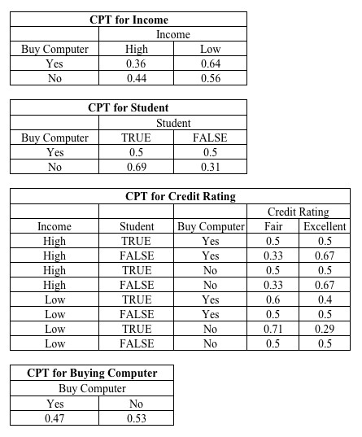

**(b)**

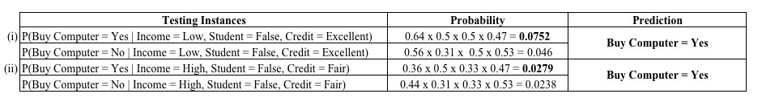

**(c)**

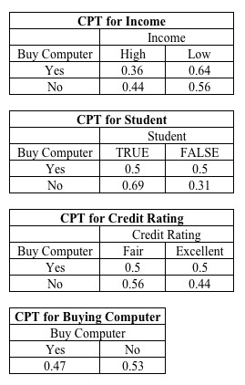

**(d)**

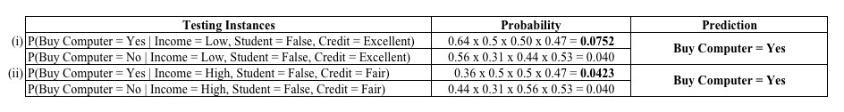

### Question 2. Decision Trees and Random Forests

**(a)**

```r
library(tree)

# Room Occupancy Training Data
training_data = read.delim("/Users/Geoff/Documents/Data Science MSc/Semester 1 October 2019/Big Data Analytics Using R (BDA)/Coursework/CW2/RoomOccupancy_Training.txt", header = TRUE, sep = ",", dec = ".")
training_data = na.omit(training_data)
training_data$Occupancy = as.factor(training_data$Occupancy)
training_data = data.frame(training_data)

# Room Occupancy Testing Data
testing_data = read.delim("/Users/Geoff/Documents/Data Science MSc/Semester 1 October 2019/Big Data Analytics Using R (BDA)/Coursework/CW2/RoomOccupancy_Testing.txt", header = TRUE, sep = ",", dec = ".")
testing_data = na.omit(testing_data)
testing_data$Occupancy = as.factor(testing_data$Occupancy)

tree.training_data = tree(Occupancy ~ ., method='class', data = training_data)
tree.predicting_using_testing = predict(tree.training_data, testing_data, type="class")
table(tree.predicting_using_testing, testing_data$Occupancy)
```

```
##
## tree.predicting_using_testing  No Yes
##                           No  195  16
##                           Yes  45  44
```

```r
(195 + 44) / 300
```

```
## [1] 0.7966667
```

The predictive performance is 0.7966667. Nearly 80% of the predictions are correct and so the predictive performance is strong. The test error rate is just over 20%.

**(b)**

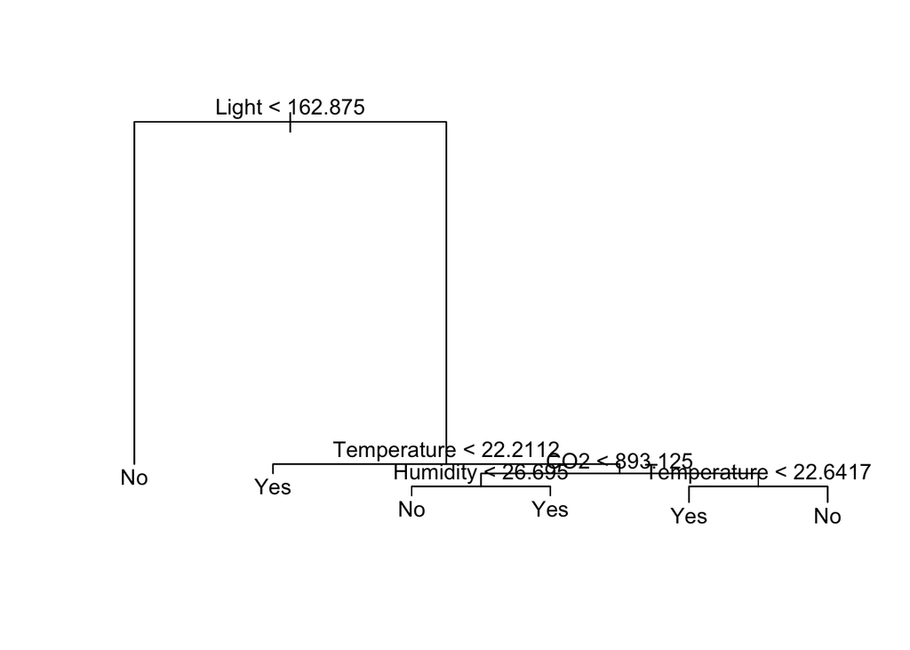

```r
plot(tree.training_data)
text(tree.training_data, pretty=0)
```

It is clear that if light is below 162.875 the room will never be occupied, regardless of the other variables. If light is above 162.875 the other variables require consideration. If light > 162.875 and temperature < 22.2112 then the room will be occupied. If the room is too warm (temperature > 22.2112) then CO2 is considered alongside humidity and again temperature.

**(c)**

```r
set.seed(004)
forest.training = randomForest(Occupancy ~ .,
                               data = training_data,
                               mtry = 5,
                               importance=TRUE)

forest.predict.test = predict(forest.training, newdata=testing_data, type="class")
table(forest.predict.test, testing_data$Occupancy)
```

```
##
## forest.predict.test  No Yes
##                 No  180  16
##                 Yes  60  44
```

```r
(180 + 44) / 300
```

```
## [1] 0.7466667
```

The predictive performance is 0.7466667. Nearly 75% of all predictions are correct and therefore the predictive performance is strong. The test error rate is just over 25%.

**(d)**

```r
importance(forest.training)
```

```
##                     No       Yes MeanDecreaseAccuracy MeanDecreaseGini
## Temperature   50.96796  29.75571             39.83069         44.93063
## Humidity      14.40781  19.27814             22.27814         11.75930
## Light         60.13400 469.63042            137.04708        706.34694
## CO2           20.75194  34.83339             39.09342         28.67146
## HumidityRatio 10.45076  18.53303             20.75262          9.54525
```

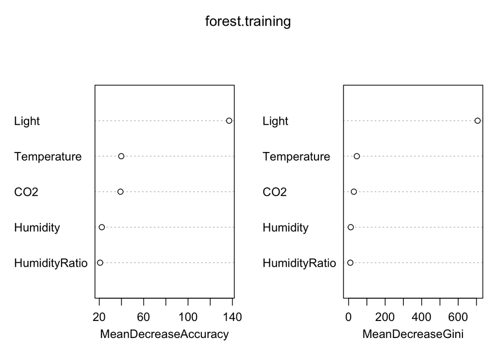

```r
varImpPlot(forest.training)
```

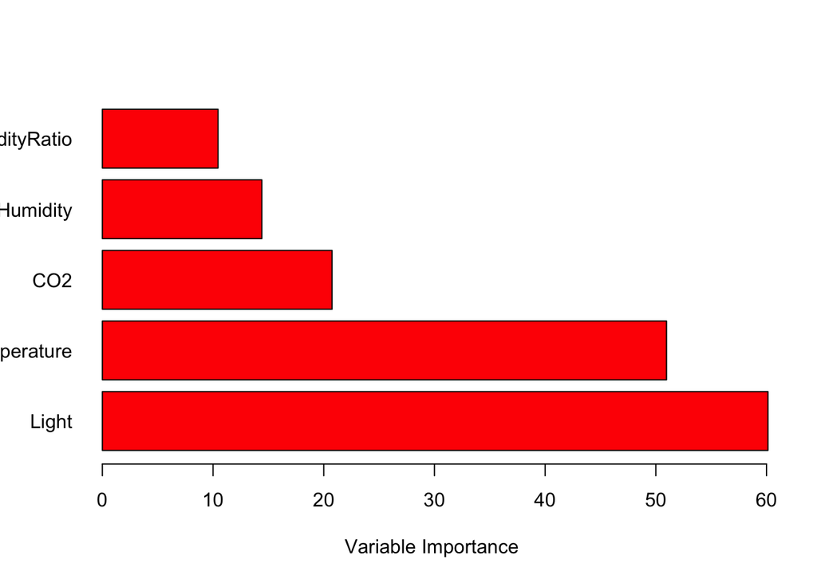

```r
barplot(sort(importance(forest.training)[,1], decreasing = TRUE), xlab = "Variable Importance",
        horiz = TRUE,
        col = "red",
        las=1)
```

### Question 3. SVM

**(a)**

```r
library(e1071)

# Wine Training Data
wine_training_data = read.delim("/Users/Geoff/Documents/Data Science MSc/Semester 1 October 2019/Big Data Analytics Using R (BDA)/Coursework/CW2/WineQuality_Training.txt", header = TRUE, sep = ",", dec = ".")
wine_training_data = na.omit(wine_training_data)
dat_training = data.frame(x=wine_training_data[0:11], y=as.factor(wine_training_data$quality))

# Wine Testing Data
wine_testing_data = read.delim("/Users/Geoff/Documents/Data Science MSc/Semester 1 October 2019/Big Data Analytics Using R (BDA)/Coursework/CW2/WineQuality_Testing.txt", header = TRUE, sep = ",", dec = ".")
wine_testing_data = na.omit(wine_testing_data)
dat_testing = data.frame(x=wine_testing_data[0:11], y=as.factor(wine_testing_data$quality))

# Finding optimal hyperparameters using linear kernal
set.seed(53)
tune.out = tune(svm , y ~ ., data = dat_training, kernel="linear", ranges=list(cost=c(0.01, 0.1, 1, 5, 10)))
summary(tune.out)
```

```
##
## Parameter tuning of 'svm':
##
## - sampling method: 10-fold cross validation
##
## - best parameters:
##  cost
##     5
##
## - best performance: 0.2426667
##
## - Detailed performance results:
##    cost     error dispersion
## 1  0.01 0.2483333 0.02902745
## 2  0.10 0.2436667 0.02795278
## 3  1.00 0.2433333 0.02114033
## 4  5.00 0.2426667 0.01837873
## 5 10.00 0.2430000 0.01773954
```

The optimal hyperparameters of svm by using the linear kernal is cost = 5.

**(b)**

```r
linear.model = svm(y~., data = dat_training, kernel="linear", cost=5, probability=TRUE)
wine_predict = predict(linear.model, newdata = dat_testing, probability=TRUE, type='prob')
table(predict=wine_predict, truth=dat_testing$y)
```

```
##        truth
## predict Bad Good
##    Bad  101   85
##    Good  41  173
```

```r
(101 + 173) / 400
```

```
## [1] 0.685
```

The predictive performance is 0.685. 68.5% are correctly predicted which is a good predictive performance. The test error rate is 31.5%.

**(c)**

```r
set.seed(12)
rbf.tune.out = tune(svm, y ~ ., data=dat_training, kernel="radial", ranges = list(cost=c(0.01, 0.1, 1, 5, 10),gamma=c(0.01, 0.03, 0.1, 0.5, 1)))
summary(rbf.tune.out)
```

```
##
## Parameter tuning of 'svm':
##
## - sampling method: 10-fold cross validation
##
## - best parameters:
##  cost gamma
##     1   0.5
##
## - best performance: 0.161
##
## - Detailed performance results:
##     cost gamma     error dispersion
## 1   0.01  0.01 0.2930000 0.03522240
## 2   0.10  0.01 0.2526667 0.02810035
## 3   1.00  0.01 0.2346667 0.03213398
## 4   5.00  0.01 0.2106667 0.03118246
## 5  10.00  0.01 0.2076667 0.03220498
## 6   0.01  0.03 0.2663333 0.02617368
## 7   0.10  0.03 0.2416667 0.02842578
## 8   1.00  0.03 0.2090000 0.02901894
## 9   5.00  0.03 0.1946667 0.03201851
## 10 10.00  0.03 0.1956667 0.03269953
## 11  0.01  0.10 0.2666667 0.03413843
## 12  0.10  0.10 0.2066667 0.03022549
## 13  1.00  0.10 0.1893333 0.03188715
## 14  5.00  0.10 0.1790000 0.02282786
## 15 10.00  0.10 0.1716667 0.02363561
## 16  0.01  0.50 0.5220000 0.02731616
## 17  0.10  0.50 0.2333333 0.03555556
## 18  1.00  0.50 0.1610000 0.02309668
## 19  5.00  0.50 0.1623333 0.02509488
## 20 10.00  0.50 0.1660000 0.02734327
## 21  0.01  1.00 0.5226667 0.02670368
## 22  0.10  1.00 0.2513333 0.07583608
## 23  1.00  1.00 0.1643333 0.02454776
## 24  5.00  1.00 0.1616667 0.02404985
## 25 10.00  1.00 0.1636667 0.02764189
```

The optimal values of the hyperparameters are cost 1 and gamma 0.5.

**(d)**

```r
rbf.model = svm(y~., data = dat_training, kernel="radial", gamma=0.5, cost=1, probability=TRUE)
rbf_wine_predict = predict(rbf.model, dat_testing, probability=TRUE)
table(predict=rbf_wine_predict, truth=dat_testing$y)
```

```
##        truth
## predict Bad Good
##    Bad  118   97
##    Good  24  161
```

```r
(118 + 161) / 400
```

```
## [1] 0.6975
```

The predictive performance is 0.6975. 69.75% are correctly predicted which is a good predictive performance. The test error rate is 30.25%.

**(e)**

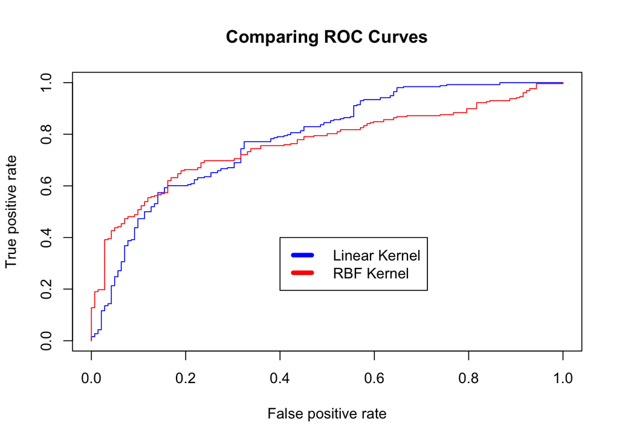

```r
# ROC plot function
rocplot = function (pred , truth, ...){
 prediction.1 = prediction (pred , truth )
 performance.1 = performance (prediction.1 , "tpr", "fpr")
}

# Linear kernel
fitted.linear = attributes(predict(linear.model,dat_testing, decision.values = TRUE))$decision.values
plot.roc.linear = rocplot(fitted.linear, dat_testing$y)

# RBF kernel
fitted.rbf = attributes(predict(rbf.model,dat_testing, decision.values = TRUE))$decision.values
plot.roc.rbf = rocplot(fitted.rbf, dat_testing$y)

# Plotting
plot(plot.roc.linear, main="Comparing ROC Curves", col="blue")
plot(plot.roc.rbf, add=TRUE, col="red")
legend(x=.4, y=.4, col = c('blue', 'red'), lty = 20, lwd = 5,
       legend = c('Linear Kernel', 'RBF Kernel'))
```

AUROC values for additional comparison:

```r
# Linear kernel workings
pred.linear = prediction(fitted.linear, dat_testing$y)
auroc.linear = performance(pred.linear, measure="auc")
auroc.value.linear = auroc.linear@y.values

# RBF kernel workings
pred.rbf = prediction(fitted.rbf, dat_testing$y)
auroc.rbf = performance(pred.rbf, measure="auc")
auroc.value.rbf = auroc.rbf@y.values

# AUROC results
auroc.value.linear
```

```
## [[1]]
## [1] 0.7833279
```

```r
auroc.value.rbf
```

```
## [[1]]
## [1] 0.762556
```

The predictive performance of the svm classifiers trained by using the linear kernel is better when compared with those using RBF kernels. The linear kernel result (0.7833279) is closer to 1 than the RBF kernel result (0.762556) and is therefore better. Interestingly, a linear kernel is a degenerate version of RBF, hence the linear kernel should never be more accurate than a properly tuned RBF kernel. This suggests that our RBF kernel has not been properly tuned (i.e. that there is a more suitable gamma that we could use in our model).

### Question 4. Hierarchical Clustering

**(a)**

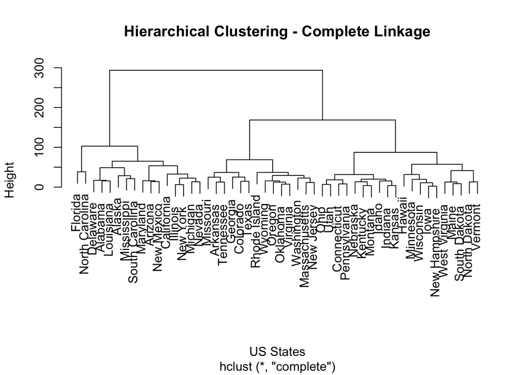

```r
library(ISLR)

clustering.complete.linkage = hclust(dist(USArrests), method = "complete")
plot(clustering.complete.linkage, main="Hierarchical Clustering - Complete Linkage", xlab="US States")
```

**(b)**

```r
cutting.dendrogram = cutree(clustering.complete.linkage, 3)
table(cutree(clustering.complete.linkage, 3))
```

```
##
##  1  2  3
## 16 14 20
```

```r
for(n in 1:3){
  print(n)
  print(rownames(USArrests)[cutting.dendrogram == n])
}
```

```
## [1] 1
##  [1] "Alabama"        "Alaska"         "Arizona"        "California"
##  [5] "Delaware"       "Florida"        "Illinois"       "Louisiana"
##  [9] "Maryland"       "Michigan"       "Mississippi"    "Nevada"
## [13] "New Mexico"     "New York"       "North Carolina" "South Carolina"
## [1] 2
##  [1] "Arkansas"      "Colorado"      "Georgia"       "Massachusetts"
##  [5] "Missouri"      "New Jersey"    "Oklahoma"      "Oregon"
##  [9] "Rhode Island"  "Tennessee"     "Texas"         "Virginia"
## [13] "Washington"    "Wyoming"
## [1] 3
##  [1] "Connecticut"   "Hawaii"        "Idaho"         "Indiana"
##  [5] "Iowa"          "Kansas"        "Kentucky"      "Maine"
##  [9] "Minnesota"     "Montana"       "Nebraska"      "New Hampshire"
## [13] "North Dakota"  "Ohio"          "Pennsylvania"  "South Dakota"
## [17] "Utah"          "Vermont"       "West Virginia" "Wisconsin"
```

Clusters 1, 2 and 3 are comprised of the corresponding states listed above.

**(c)**

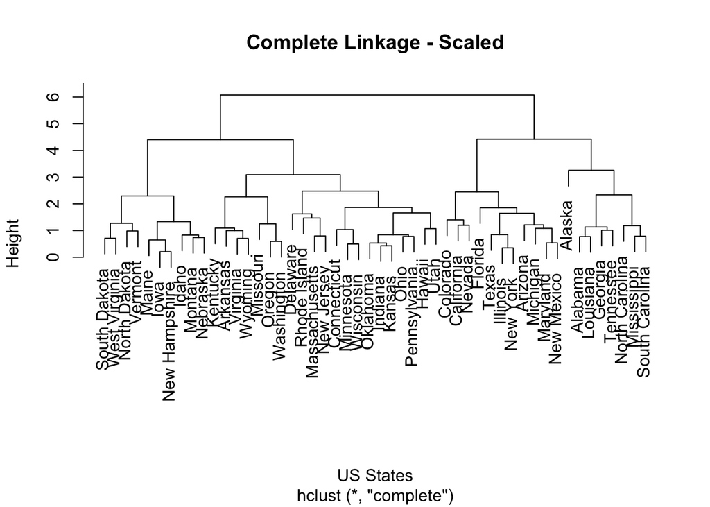

```r
scaling.hierarchical.cluster = hclust(dist(scale(USArrests)), method = "complete")
plot(scaling.hierarchical.cluster, main = "Complete Linkage - Scaled", xlab="US States")
```

The above is a hierarchical cluster of the states using complete linkage and Euclidean distance after scaling the variables to have standard deviation one.

**(d)**

```r
cut.scaling = cutree(scaling.hierarchical.cluster, 3)
table(cut.scaling)
```

```
## cut.scaling
##  1  2  3
##  8 11 31
```

```r
table(unscaled = cutting.dendrogram, scaled = cut.scaling)
```

```
##         scaled
## unscaled  1  2  3
##        1  6  9  1
##        2  2  2 10
##        3  0  0 20
```

```r
for(n in 1:3){
  print(n)
  print(rownames(USArrests)[cutting.dendrogram == n])
} # Not scaling the variables produces the following hierarchical clustering:
```

```
## [1] 1
##  [1] "Alabama"        "Alaska"         "Arizona"        "California"
##  [5] "Delaware"       "Florida"        "Illinois"       "Louisiana"
##  [9] "Maryland"       "Michigan"       "Mississippi"    "Nevada"
## [13] "New Mexico"     "New York"       "North Carolina" "South Carolina"
## [1] 2
##  [1] "Arkansas"      "Colorado"      "Georgia"       "Massachusetts"
##  [5] "Missouri"      "New Jersey"    "Oklahoma"      "Oregon"
##  [9] "Rhode Island"  "Tennessee"     "Texas"         "Virginia"
## [13] "Washington"    "Wyoming"
## [1] 3
##  [1] "Connecticut"   "Hawaii"        "Idaho"         "Indiana"
##  [5] "Iowa"          "Kansas"        "Kentucky"      "Maine"
##  [9] "Minnesota"     "Montana"       "Nebraska"      "New Hampshire"
## [13] "North Dakota"  "Ohio"          "Pennsylvania"  "South Dakota"
## [17] "Utah"          "Vermont"       "West Virginia" "Wisconsin"
```

```r
for(n in 1:3){
  print(n)
  print(rownames(USArrests)[cut.scaling == n])
} # Scaling the variables produces the following hierarchical clustering:
```

```
## [1] 1
## [1] "Alabama"        "Alaska"         "Georgia"        "Louisiana"
## [5] "Mississippi"    "North Carolina" "South Carolina" "Tennessee"
## [1] 2
##  [1] "Arizona"    "California" "Colorado"   "Florida"    "Illinois"
##  [6] "Maryland"   "Michigan"   "Nevada"     "New Mexico" "New York"
## [11] "Texas"
## [1] 3
##  [1] "Arkansas"      "Connecticut"   "Delaware"      "Hawaii"
##  [5] "Idaho"         "Indiana"       "Iowa"          "Kansas"
##  [9] "Kentucky"      "Maine"         "Massachusetts" "Minnesota"
## [13] "Missouri"      "Montana"       "Nebraska"      "New Hampshire"
## [17] "New Jersey"    "North Dakota"  "Ohio"          "Oklahoma"
## [21] "Oregon"        "Pennsylvania"  "Rhode Island"  "South Dakota"
## [25] "Utah"          "Vermont"       "Virginia"      "Washington"
## [29] "West Virginia" "Wisconsin"     "Wyoming"
```

We can see from the table above (unscaled vs scaled) and from printing each hierarchical clustering that, when comparing the two clusterings (scaled and unscaled), scaling impacts which states go into which cluster and therefore the clusters differ.

```r
var(USArrests)
```

```
##              Murder   Assault   UrbanPop      Rape
## Murder    18.970465  291.0624   4.386204  22.99141
## Assault  291.062367 6945.1657 312.275102 519.26906
## UrbanPop   4.386204  312.2751 209.518776  55.76808
## Rape      22.991412  519.2691  55.768082  87.72916
```

In this situation it is advisable to scale the data as we are unsure about the relationship between each attribute (Murder, Assault, UrbanPop, Rape) - the attributes have different units of measurement. Murder, Rape, and Assault are reported as the number of occurrences per 100,000 people whereas UrbanPop is the percentage of the state’s population living in an urban area. Scaling will also avoid giving attributes with larger magnitudes more importance. In this instance, if the data was unscaled, Assault would be given more importance as it has much higher variance than the other attributes.

### Question 5. PCA and K-Means Clustering

**(a)**

```r
set.seed(127)
labels = c(rep(1,20),rep(2,20),rep(3,20))

X = rbind(matrix(rnorm(20*50), nrow = 20, ncol=50),
           matrix(rnorm(20*50), nrow = 20, ncol=50),
           matrix(rnorm(20*50), nrow = 20, ncol=50))

X[labels==1,] = X[labels==1,] + rep(1, 50)
X[labels==2,] = X[labels==2,] + rep(-1, 50)
X[labels==3,] = X[labels==3,] + c(rep(+1, 50/2), rep(-1, 50/2))
```

**(b)**

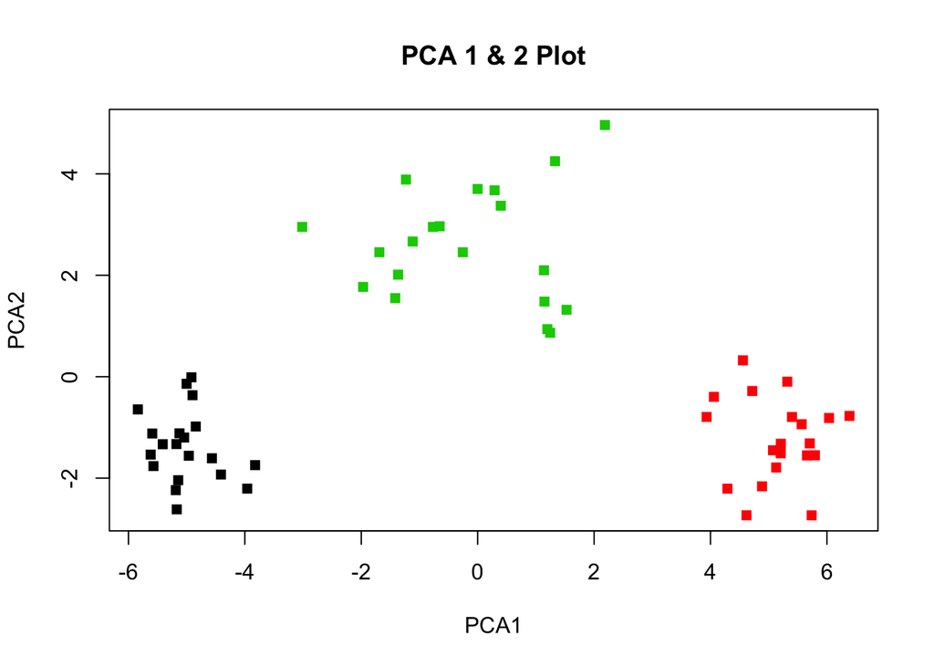

```r
pr.out = prcomp(X, scale=TRUE)
plot(pr.out$x[,1:2], col=labels, main="PCA 1 & 2 Plot", xlab="PCA1", ylab="PCA2", pch=15)
```

**(c)**

```r
kmeans.k3 = kmeans(X, 3, nstart=200)
table(clustered = kmeans.k3$cluster, original = labels)
```

```
##          original
## clustered  1  2  3
##         1  0 20  0
##         2 20  0  0
##         3  0  0 20
```

We can see that all three original classes (all 20 samples for each of class) fell into seperate clusters. The clusters obtained from K-means clustering are therefore identical to the true class labels.

**(d)**

```r
kmeans.k2 = kmeans(X, 2, nstart=200)
table(clustered = kmeans.k2$cluster, original = labels)
```

```
##          original
## clustered  1  2  3
##         1 20  0 12
##         2  0 20  8
```

**(e)**

```r
kmeans.k4 = kmeans(X, 4, nstart=200)
table(clustered = kmeans.k4$cluster, original = labels)
```

```
##          original
## clustered  1  2  3
##         1  0  0 10
##         2 20  0  0
##         3  0 20  0
##         4  0  0 10
```

**(f)**

```r
kmeans.principal.component.k3 = kmeans(pr.out$x[,1:2], 3, nstart=200)
table(clustered = kmeans.principal.component.k3$cluster, original = labels)
```

```
##          original
## clustered  1  2  3
##         1 20  0  0
##         2  0  0 20
##         3  0 20  0
```

We can see that all three original classes (all 20 samples for each of class) fell into seperate clusters. The clusters obtained are therefore identical to the true class labels.

**(g)**

```r
kmeans.scaled.k3 = kmeans(scale(X), 3, nstart = 200)
table(clustered = kmeans.scaled.k3$cluster, original = labels)
```

```
##          original
## clustered  1  2  3
##         1  0  0 20
##         2  0 20  0
##         3 20  0  0
```

The results are the same and therefore scaling doesn’t effect the clustering at all.